# All Children’s Eye Gaze (study2children)

Adam Stone, PhD

10-31-2017

# All Children!

We’re importing *both* the child and baby data. Let’s get a chart of how old all our kids are.

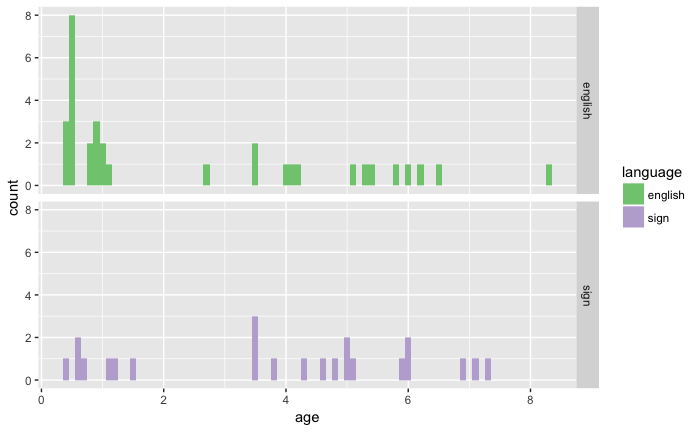

```r
# Libraries
library(tidyverse)
library(feather)
library(scales)
library(stringr)
library(viridis)
library(lme4)
library(lmerTest)
library(RColorBrewer)
#library(cowplot)
# Import data that's been cleaned up from 01importclean
babydata <- read_feather("cleanedbabyeyedata.feather")
kiddata <- read_feather("cleanedchildeyedata.feather")
data <- rbind(babydata,kiddata)
data_ages <- data %>%
  select(participant, language, age, group) %>%
  distinct()
ggplot(data_ages, aes(x = age, fill = language)) + geom_histogram(binwidth = 0.1) + facet_grid(language ~ .) + scale_fill_brewer(palette = "Accent")
```

Next, let’s do boxplots of each AOI across all stories and kids, grouping for forward vs. reversed.

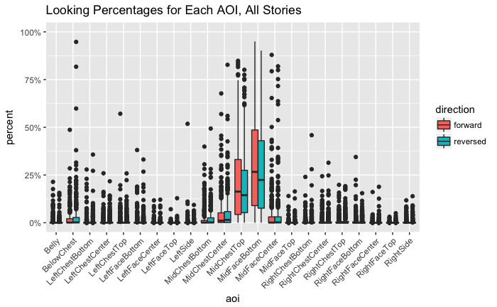

```r
# Boxplot!
ggplot(data, aes(x = aoi, y = percent, fill = direction)) +
  geom_boxplot() + theme(axis.text.x = element_text(angle=45, hjust = 1)) +
  ggtitle("Looking Percentages for Each AOI, All Stories") +
  scale_y_continuous(labels = scales::percent, limits = c(0,1))
```

Looks like by far most of the activity is along the Mid** AOIs. Let’s look closer.

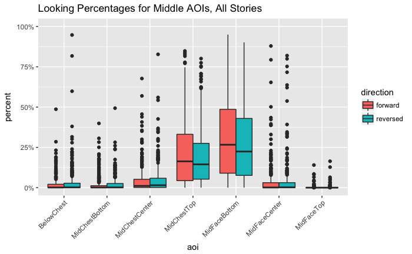

```r
data_mid <- data %>%
  filter(str_detect(aoi,"Mid") | aoi == "BelowChest")
ggplot(data_mid, aes(x = aoi, y = percent, fill = direction)) +
  geom_boxplot() + theme(axis.text.x = element_text(angle=45, hjust = 1)) +
  ggtitle("Looking Percentages for Middle AOIs, All Stories") +
  scale_y_continuous(labels = scales::percent, limits = c(0,1))
```

As a preliminary analysis I’m going to just look at MidChestTop and MidFaceBottom. Are there differences based on direction, group, or age for either AOI?

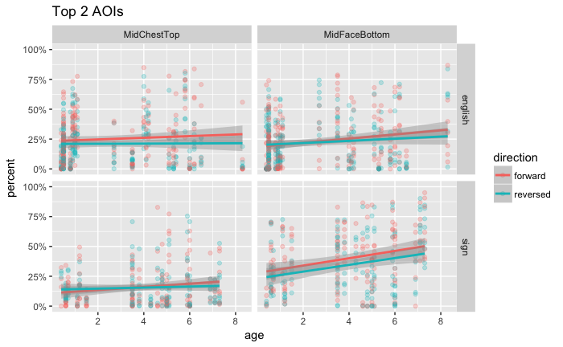

```r
data_mid %>%
  filter(aoi == "MidChestTop" | aoi == "MidFaceBottom") %>%
  ggplot(aes(x = age, y = percent, color = direction)) + geom_point(alpha = 0.25) +
  geom_smooth(method = "lm") + facet_grid(language ~ aoi) +
  scale_y_continuous(labels = scales::percent, limits = c(0,1)) +
  ggtitle("Top 2 AOIs")
```

I am not observing big differences for direction. And not strong patterns across age, although there are subtle upward trends for increased chest looking in NSE kids as they get older, but increased face looking in CODAS as they get older.

What if we defined a Face-Chest Ratio (FCR) such that:

1. MidFaceCenter, MidFaceBottom = Face
2. MidChestTop, MidChestCenter, MidChestBottom, BelowChest = Chest
3. FCR = face - chest / face + chest

Let’s try that. Let’s also try only MidFaceBottom vs. MidChestTop too, and call that MFCR (for middle-middle).

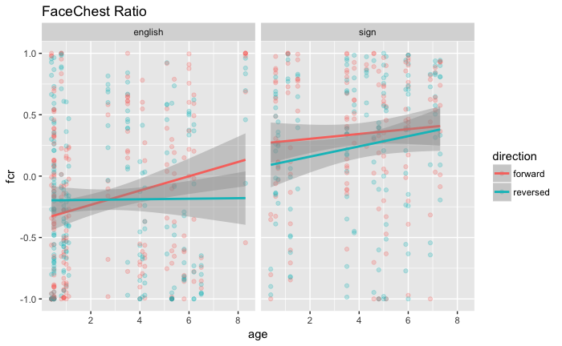

```r
data_mid <- data_mid %>%
  select(-secs, -hits) %>%
  spread(aoi,percent) %>%
  group_by(participant, trial) %>%
  mutate(face = sum(MidFaceCenter, MidFaceBottom, na.rm = TRUE),
         chest = sum(MidChestTop, MidChestCenter, MidChestBottom, BelowChest, na.rm = TRUE),
         fcr = (face - chest) / (face + chest),
         mfcr = (MidFaceBottom - MidChestTop) / (MidFaceBottom + MidChestTop))
ggplot(data_mid, aes(x = age, y = fcr, color = direction)) + geom_point(alpha = 0.25) +
  geom_smooth(method = "lm") + facet_wrap("language") + ggtitle("FaceChest Ratio")
```

Let’s also check out MFCR (a stricter ratio). Almost the same thing.

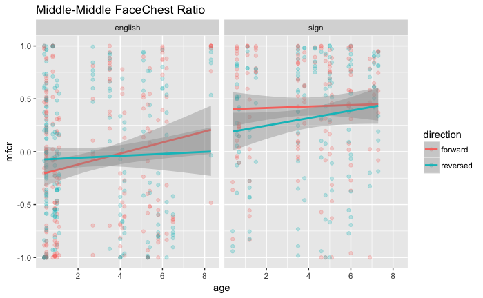

```r
ggplot(data_mid, aes(x = age, y = mfcr, color = direction)) + geom_point(alpha = 0.25) +
  geom_smooth(method = "lm") + facet_wrap("language") + ggtitle("Middle-Middle FaceChest Ratio")
```

So this is rad! Such obvious group differences should also be reflected in a heat map that is collapsed across age and direction. And the heat map below shows that CODAs really focus on the MidFaceBottom AOI, while English-exposed children are a bit more spread out, looking much more at the chest.

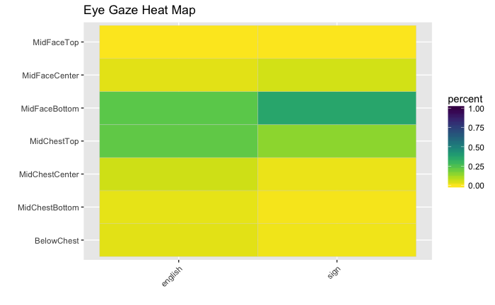

```r
data_mid_heat <- data_mid %>%
  ungroup() %>%
  select(-face, -chest, -fcr, -mfcr) %>%
  gather(aoi, percent, BelowChest:MidFaceTop) %>%
  group_by(language, participant, direction, aoi) %>%
  summarise(percent = mean(percent, na.rm = TRUE)) %>%
  group_by(language, direction, aoi) %>%
  summarise(percent = mean(percent, na.rm = TRUE)) %>%
  group_by(language, aoi) %>%
  summarise(percent = mean(percent, na.rm = TRUE)) %>%
  mutate(aoi = factor(aoi, levels = c("BelowChest", "MidChestBottom", "MidChestCenter", "MidChestTop",
                                      "MidFaceBottom", "MidFaceCenter", "MidFaceTop")))
ggplot(data_mid_heat, aes(x = language, y = aoi)) +
  geom_tile(aes(fill=percent),color="lightgray",na.rm=TRUE) +
  scale_fill_viridis(option = "viridis", direction=-1, limits = c(0,1)) +
  theme(axis.text.x=element_text(angle=45,hjust=1)) +
  ylab("") + xlab("") + ggtitle("Eye Gaze Heat Map")
```

# Statistical Testing of FCR/mFCR

Now that we’ve found something interesting with FCR and mFCR, let’s see if it holds up in stats modeling.

## Language, Direction, & Age Predictors

First, a LMM with predictors Language, Direction, and Age, and outcome variable FCR.

Here, some interesting effects (and this model was NOT working with just babies and children!).

```r
fcr_lmm <- lmer(fcr ~ age * language * direction + (1|story) + (1|participant), data = data_mid)
summary(fcr_lmm)
```

```
Linear mixed model fit by REML t-tests use Satterthwaite approximations to degrees of freedom [lmerMod]
Formula: fcr ~ age * language * direction + (1 | story) + (1 | participant)
   Data: data_mid

REML criterion at convergence: 1051.6

Scaled residuals:
    Min      1Q  Median      3Q     Max
-3.1861 -0.5796  0.0506  0.6523  2.6752

Random effects:
 Groups      Name        Variance Std.Dev.
 participant (Intercept) 0.186281 0.43160
 story       (Intercept) 0.008095 0.08997
 Residual                0.193237 0.43959
Number of obs: 727, groups:  participant, 56; story, 8

Fixed effects:
                                    Estimate Std. Error        df t value Pr(>|t|)
(Intercept)                         -0.29338    0.12315  64.00000  -2.382   0.0202 *
age                                  0.04361    0.03435  59.00000   1.270   0.2092
languagesign                         0.52863    0.22722  59.00000   2.327   0.0234 *
directionreversed                    0.13098    0.06399 662.40000   2.047   0.0411 *
age:languagesign                    -0.01312    0.05545  58.80000  -0.237   0.8138
age:directionreversed               -0.04024    0.01872 658.10000  -2.150   0.0319 *
languagesign:directionreversed      -0.30884    0.12246 661.10000  -2.522   0.0119 *
age:languagesign:directionreversed   0.05375    0.02987 666.80000   1.800   0.0724 .
---
Signif. codes:  0 ‘***’ 0.001 ‘**’ 0.01 ‘*’ 0.05 ‘.’ 0.1 ‘ ’ 1

Correlation of Fixed Effects:
            (Intr) age    lnggsg drctnr ag:lng ag:drc lnggs:
age         -0.707
languagesgn -0.506  0.383
dirctnrvrsd -0.257  0.198  0.139
age:lnggsgn  0.438 -0.620 -0.816 -0.123
ag:drctnrvr  0.189 -0.270 -0.103 -0.735  0.169
lnggsgn:drc  0.134 -0.104 -0.259 -0.523  0.213  0.385
ag:lnggsgn: -0.119  0.171  0.213  0.463 -0.264 -0.634 -0.816
```

Let’s repeat the LMM with outcome mFCR. Stronger statistical values.

```r
mfcr_lmm <- lmer(mfcr ~ age * language * direction + (1|story) + (1|participant), data = data_mid)
summary(mfcr_lmm)
```

```
Linear mixed model fit by REML t-tests use Satterthwaite approximations to degrees of freedom [lmerMod]
Formula: mfcr ~ age * language * direction + (1 | story) + (1 | participant)
   Data: data_mid

REML criterion at convergence: 1103.2

Scaled residuals:
    Min      1Q  Median      3Q     Max
-3.2209 -0.5907  0.0889  0.6690  2.6702

Random effects:
 Groups      Name        Variance Std.Dev.
 participant (Intercept) 0.1790   0.42304
 story       (Intercept) 0.0054   0.07348
 Residual                0.2149   0.46360
Number of obs: 716, groups:  participant, 56; story, 8

Fixed effects:
                                    Estimate Std. Error        df t value Pr(>|t|)
(Intercept)                         -0.18629    0.12101  64.30000  -1.540  0.12858
age                                  0.04077    0.03406  60.00000   1.197  0.23601
languagesign                         0.53906    0.22591  60.60000   2.386  0.02016 *
directionreversed                    0.14988    0.06810 652.20000   2.201  0.02809 *
age:languagesign                    -0.02018    0.05504  60.10000  -0.367  0.71511
age:directionreversed               -0.03256    0.01982 631.10000  -1.642  0.10100
languagesign:directionreversed      -0.34732    0.12997 650.40000  -2.672  0.00772 **
age:languagesign:directionreversed   0.05027    0.03165 653.80000   1.588  0.11274
---
Signif. codes:  0 ‘***’ 0.001 ‘**’ 0.01 ‘*’ 0.05 ‘.’ 0.1 ‘ ’ 1

Correlation of Fixed Effects:
            (Intr) age    lnggsg drctnr ag:lng ag:drc lnggs:
age         -0.715
languagesgn -0.511  0.383
dirctnrvrsd -0.280  0.212  0.150
age:lnggsgn  0.443 -0.619 -0.817 -0.132
ag:drctnrvr  0.206 -0.286 -0.110 -0.736  0.179
lnggsgn:drc  0.147 -0.111 -0.282 -0.524  0.230  0.386
ag:lnggsgn: -0.129  0.181  0.230  0.463 -0.283 -0.632 -0.817
```

## Direction & Language Predictors

In the LMMs we’ve run so far, age is always the worst predictor. So we should take that out.

1. *NEED TO UPDATE WRITE-UP…ADDED MORE BABIES*
2. Strong effect of language (p < 0.001)
3. Significant language x direction interaction (p = 0.02).

```r
fcr_lmm_noage <- lmer(fcr ~ direction * language + (1|story) + (1|participant), data = data_mid)
summary(fcr_lmm_noage)
```

```
Linear mixed model fit by REML t-tests use Satterthwaite approximations to degrees of freedom [lmerMod]
Formula: fcr ~ direction * language + (1 | story) + (1 | participant)
   Data: data_mid

REML criterion at convergence: 1036.5

Scaled residuals:
    Min      1Q  Median      3Q     Max
-3.1674 -0.6023  0.0594  0.6522  2.5727

Random effects:
 Groups      Name        Variance Std.Dev.
 participant (Intercept) 0.184903 0.43000
 story       (Intercept) 0.008229 0.09071
 Residual                0.193963 0.44041
Number of obs: 727, groups:  participant, 56; story, 8

Fixed effects:
                                Estimate Std. Error        df t value Pr(>|t|)
(Intercept)                     -0.18330    0.08702  61.10000  -2.106   0.0393 *
directionreversed                0.03003    0.04346 668.90000   0.691   0.4899
languagesign                     0.53656    0.12614  61.10000   4.254 7.34e-05 ***
directionreversed:languagesign  -0.15590    0.06766 668.70000  -2.304   0.0215 *
---
Signif. codes:  0 ‘***’ 0.001 ‘**’ 0.01 ‘*’ 0.05 ‘.’ 0.1 ‘ ’ 1

Correlation of Fixed Effects:
            (Intr) drctnr lnggsg
dirctnrvrsd -0.247
languagesgn -0.596  0.172
drctnrvrsd:  0.160 -0.649 -0.264
```

The mFCR LMM gives us similar results. *NEED TO UPDATE WRITE-UP…ADDED MORE BABIES*

```r
mfcr_lmm_noage <- lmer(mfcr ~ direction * language + (1|story) + (1|participant), data = data_mid)
summary(mfcr_lmm_noage)
```

```
Linear mixed model fit by REML t-tests use Satterthwaite approximations to degrees of freedom [lmerMod]
Formula: mfcr ~ direction * language + (1 | story) + (1 | participant)
   Data: data_mid

REML criterion at convergence: 1086.4

Scaled residuals:
    Min      1Q  Median      3Q     Max
-3.2141 -0.5971  0.1001  0.6560  2.5850

Random effects:
 Groups      Name        Variance Std.Dev.
 participant (Intercept) 0.176484 0.42010
 story       (Intercept) 0.005464 0.07392
 Residual                0.215222 0.46392
Number of obs: 716, groups:  participant, 56; story, 8

Fixed effects:
                                Estimate Std. Error        df t value Pr(>|t|)
(Intercept)                     -0.08262    0.08420  63.00000  -0.981 0.330225
directionreversed                0.06758    0.04610 657.30000   1.466 0.143161
languagesign                     0.51504    0.12482  62.30000   4.126 0.000111 ***
directionreversed:languagesign  -0.19644    0.07178 658.80000  -2.737 0.006376 **
---
Signif. codes:  0 ‘***’ 0.001 ‘**’ 0.01 ‘*’ 0.05 ‘.’ 0.1 ‘ ’ 1

Correlation of Fixed Effects:
            (Intr) drctnr lnggsg
dirctnrvrsd -0.271
languagesgn -0.610  0.185
drctnrvrsd:  0.176 -0.649 -0.284
```

## Separate for direction

Forward only. Language effect, p < 0.001. (I ran this WITH age, and age was not significant). *NEED TO UPDATE WRITE-UP…ADDED MORE BABIES*

```r
fcr_lmm_langonly_f <- lmer(fcr ~ language + (1|story) + (1|participant), data = filter(data_mid,direction=="forward"))
summary(fcr_lmm_langonly_f)
```

```
Linear mixed model fit by REML t-tests use Satterthwaite approximations to degrees of freedom [lmerMod]
Formula: fcr ~ language + (1 | story) + (1 | participant)
   Data: filter(data_mid, direction == "forward")

REML criterion at convergence: 513.7

Scaled residuals:
    Min      1Q  Median      3Q     Max
-3.1723 -0.5106  0.0275  0.5872  2.4914

Random effects:
 Groups      Name        Variance Std.Dev.
 participant (Intercept) 0.19540  0.4420
 story       (Intercept) 0.03001  0.1732
 Residual                0.16197  0.4025
Number of obs: 368, groups:  participant, 56; story, 8

Fixed effects:
             Estimate Std. Error      df t value Pr(>|t|)
(Intercept)   -0.1871     0.1028 30.4200  -1.820 0.078658 .
languagesign   0.5340     0.1284 52.8700   4.159 0.000118 ***
---
Signif. codes:  0 ‘***’ 0.001 ‘**’ 0.01 ‘*’ 0.05 ‘.’ 0.1 ‘ ’ 1

Correlation of Fixed Effects:
            (Intr)
languagesgn -0.518
```

```r
fcr_lmm_langonly_r <- lmer(fcr ~ language + (1|story) + (1|participant), data = filter(data_mid,direction=="reversed"))
summary(fcr_lmm_langonly_r)
```

```
Linear mixed model fit by REML t-tests use Satterthwaite approximations to degrees of freedom [lmerMod]
Formula: fcr ~ language + (1 | story) + (1 | participant)
   Data: filter(data_mid, direction == "reversed")

REML criterion at convergence: 572.6

Scaled residuals:
     Min       1Q   Median       3Q      Max
-3.04814 -0.54162  0.03133  0.66742  2.76008

Random effects:
 Groups      Name        Variance Std.Dev.
 participant (Intercept) 0.15693  0.3961
 story       (Intercept) 0.01582  0.1258
 Residual                0.21241  0.4609
Number of obs: 359, groups:  participant, 56; story, 8

Fixed effects:
             Estimate Std. Error       df t value Pr(>|t|)
(Intercept)  -0.15279    0.08865 34.82000  -1.724  0.09366 .
languagesign  0.38357    0.11946 52.28000   3.211  0.00226 **
---
Signif. codes:  0 ‘***’ 0.001 ‘**’ 0.01 ‘*’ 0.05 ‘.’ 0.1 ‘ ’ 1

Correlation of Fixed Effects:
            (Intr)
languagesgn -0.557
```

Let’s go ahead and plot boxplots to represent LMMs with only language as an important effect. (We can add in direction too). FaceChest Ratio here.

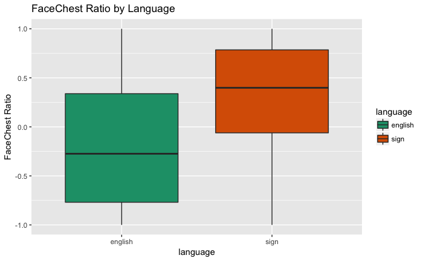

```r
ggplot(data_mid, aes(x = language, y = fcr, fill = language)) + geom_boxplot() + scale_fill_brewer(palette = "Dark2") + ylab("FaceChest Ratio") + ggtitle("FaceChest Ratio by Language")
```

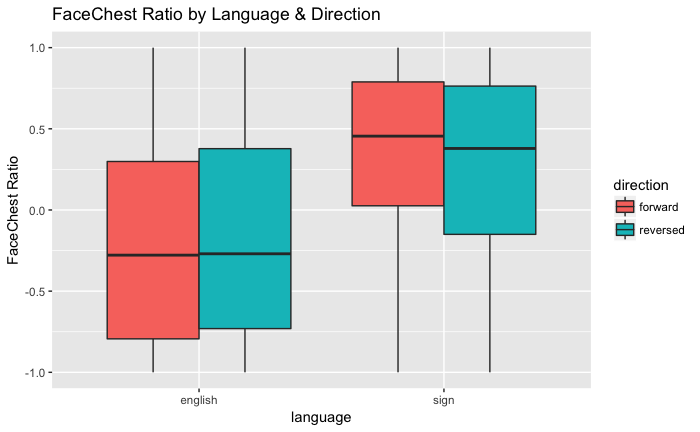

```r
ggplot(data_mid, aes(x = language, y = fcr, fill = direction)) + geom_boxplot() + ylab("FaceChest Ratio") + ggtitle("FaceChest Ratio by Language & Direction")
```

And Middle-Middle FaceChest Ratio here.

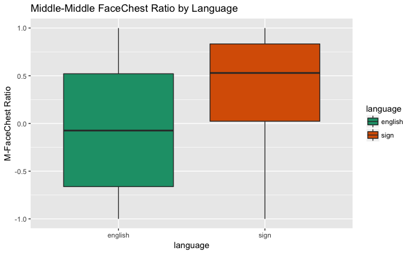

```r
ggplot(data_mid, aes(x = language, y = mfcr, fill = language)) + geom_boxplot() + scale_fill_brewer(palette = "Dark2") + ylab("M-FaceChest Ratio") + ggtitle("Middle-Middle FaceChest Ratio by Language")
```

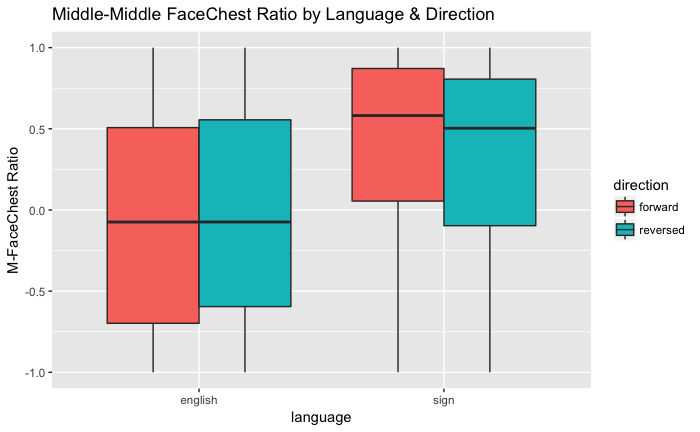

```r
ggplot(data_mid, aes(x = language, y = mfcr, fill = direction)) + geom_boxplot() + ylab("M-FaceChest Ratio") + ggtitle("Middle-Middle FaceChest Ratio by Language & Direction")
```

Maybe error bars would be nice here. Let’s do it.

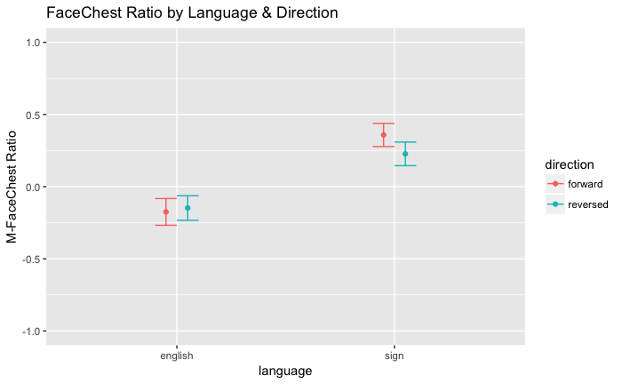

```r
data_mid_fcr <- data_mid %>%
  group_by(language, participant, direction) %>%
  summarise(fcr_mean_subj = mean(fcr, na.rm=TRUE)) %>%
  group_by(language, direction) %>%
  summarise(fcr_mean = mean(fcr_mean_subj, na.rm=TRUE),
            fcr_sd = sd(fcr_mean_subj, na.rm=TRUE),
            fcr_n = n()) %>%
  ungroup() %>%
  mutate(fcr_se = fcr_sd/sqrt(fcr_n))
ggplot(data_mid_fcr, aes(x = language, y = fcr_mean, color = direction, group = direction, fill = direction)) + geom_errorbar(aes(ymin = fcr_mean-fcr_se, ymax = fcr_mean+fcr_se), position = "dodge", width = 0.2) +
  geom_point(position = position_dodge(width = 0.2)) + scale_y_continuous(limits = c(-1,1)) + ylab("M-FaceChest Ratio") + ggtitle("FaceChest Ratio by Language & Direction")
```

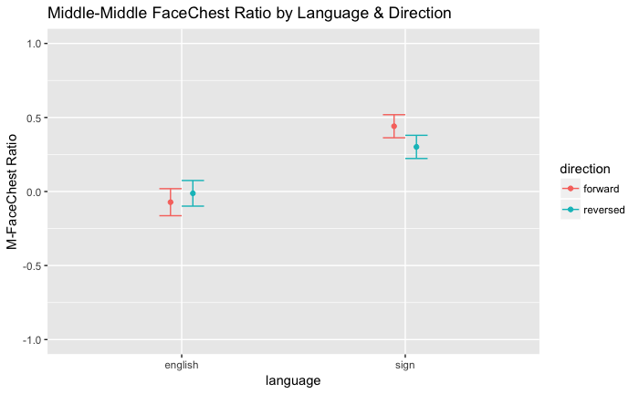

```r
data_mid_mfcr <- data_mid %>%
  group_by(language, participant, direction) %>%
  summarise(fcr_mean_subj = mean(mfcr, na.rm=TRUE)) %>%
  group_by(language, direction) %>%
  summarise(fcr_mean = mean(fcr_mean_subj, na.rm=TRUE),
            fcr_sd = sd(fcr_mean_subj, na.rm=TRUE),
            fcr_n = n()) %>%
  ungroup() %>%
  mutate(fcr_se = fcr_sd/sqrt(fcr_n))
ggplot(data_mid_mfcr, aes(x = language, y = fcr_mean, color = direction, group = direction, fill = direction)) + geom_errorbar(aes(ymin = fcr_mean-fcr_se, ymax = fcr_mean+fcr_se), position = "dodge", width = 0.2) +
  geom_point(position = position_dodge(width = 0.2)) + scale_y_continuous(limits = c(-1,1)) + ylab("M-FaceChest Ratio") + ggtitle("Middle-Middle FaceChest Ratio by Language & Direction")
```

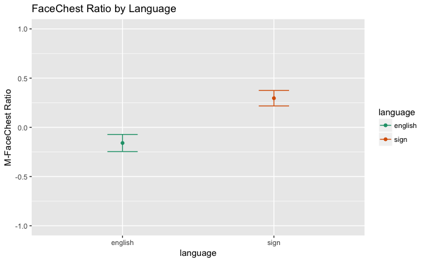

```r
data_mid_fcr <- data_mid %>%
  group_by(language, participant) %>%
  summarise(fcr_mean_subj = mean(fcr, na.rm=TRUE)) %>%
  group_by(language) %>%
  summarise(fcr_mean = mean(fcr_mean_subj, na.rm=TRUE),
            fcr_sd = sd(fcr_mean_subj, na.rm=TRUE),
            fcr_n = n()) %>%
  ungroup() %>%
  mutate(fcr_se = fcr_sd/sqrt(fcr_n))
ggplot(data_mid_fcr, aes(x = language, y = fcr_mean, color = language)) + geom_errorbar(aes(ymin = fcr_mean-fcr_se, ymax = fcr_mean+fcr_se), width = 0.2) +
  geom_point() + scale_y_continuous(limits = c(-1,1)) + ylab("M-FaceChest Ratio") + ggtitle("FaceChest Ratio by Language") + scale_color_brewer(palette = "Dark2")
```

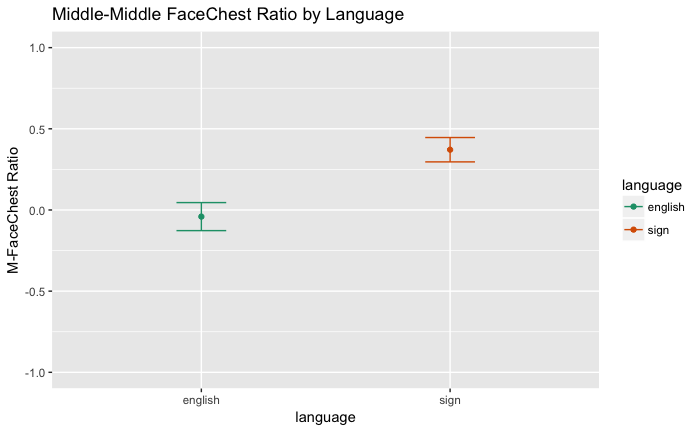

```r
data_mid_mfcr <- data_mid %>%
  group_by(language, participant) %>%
  summarise(fcr_mean_subj = mean(mfcr, na.rm=TRUE)) %>%
  group_by(language) %>%
  summarise(fcr_mean = mean(fcr_mean_subj, na.rm=TRUE),
            fcr_sd = sd(fcr_mean_subj, na.rm=TRUE),
            fcr_n = n()) %>%
  ungroup() %>%
  mutate(fcr_se = fcr_sd/sqrt(fcr_n))
ggplot(data_mid_mfcr, aes(x = language, y = fcr_mean, color = language)) + geom_errorbar(aes(ymin = fcr_mean-fcr_se, ymax = fcr_mean+fcr_se), width = 0.2) +
  geom_point() + scale_y_continuous(limits = c(-1,1)) + ylab("M-FaceChest Ratio") + ggtitle("Middle-Middle FaceChest Ratio by Language") + scale_color_brewer(palette = "Dark2")
```

# Are Babies and Children Different?

Quick check here. First, are CODA babies different from CODA children?

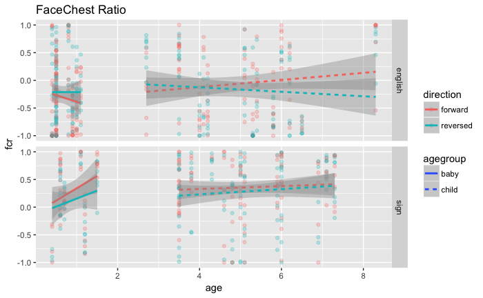

```r
data_mid <- data_mid %>%
  mutate(agegroup = ifelse(age < 2, "baby", "child")) %>%
  mutate(agegroup = as.factor(agegroup))
ggplot(data_mid, aes(x = age, y = fcr, color = direction)) + geom_point(alpha = 0.25) +
  geom_smooth(method = "lm", aes(linetype = agegroup)) + facet_grid(language ~ .) + ggtitle("FaceChest Ratio")
```

Let’s do a LMM with agegroup

```r
agegroup_lmm <- lmer(fcr ~ agegroup * direction * language + (1|story) + (1|participant), data = data_mid)
summary(agegroup_lmm)
```

```
Linear mixed model fit by REML t-tests use Satterthwaite approximations to degrees of freedom [lmerMod]
Formula: fcr ~ agegroup * direction * language + (1 | story) + (1 | participant)
   Data: data_mid

REML criterion at convergence: 1041

Scaled residuals:
    Min      1Q  Median      3Q     Max
-3.2017 -0.5904  0.0549  0.6484  2.6514

Random effects:
 Groups      Name        Variance Std.Dev.
 participant (Intercept) 0.187558 0.43308
 story       (Intercept) 0.008123 0.09013
 Residual                0.193704 0.44012
Number of obs: 727, groups:  participant, 56; story, 8

Fixed effects:
                                              Estimate Std. Error        df t value Pr(>|t|)
(Intercept)                                   -0.26739    0.11215  63.80000  -2.384   0.0201 *
agegroupchild                                  0.19672    0.16452  58.60000   1.196   0.2366
directionreversed                              0.09569    0.05752 660.30000   1.664   0.0967 .
languagesign                                   0.53514    0.20678  58.90000   2.588   0.0121 *
agegroupchild:directionreversed               -0.15272    0.08741 666.70000  -1.747   0.0811 .
agegroupchild:languagesign                    -0.07464    0.26825  58.70000  -0.278   0.7818
directionreversed:languagesign                -0.25213    0.11129 660.10000  -2.266   0.0238 *
agegroupchild:directionreversed:languagesign   0.19672    0.14399 666.60000   1.366   0.1723
---
Signif. codes:  0 ‘***’ 0.001 ‘**’ 0.01 ‘*’ 0.05 ‘.’ 0.1 ‘ ’ 1

Correlation of Fixed Effects:
            (Intr) aggrpc drctnr lnggsg aggrpchld:d aggrpchld:l drctn:
agegropchld -0.627
dirctnrvrsd -0.253  0.172
languagesgn -0.498  0.340  0.137
aggrpchld:d  0.167 -0.264 -0.656 -0.092
aggrpchld:l  0.384 -0.614 -0.105 -0.771  0.165
drctnrvrsd:  0.131 -0.090 -0.516 -0.257  0.343       0.198
aggrpchld:: -0.101  0.163  0.397  0.200 -0.616      -0.261      -0.775
```

LMM here for CODA babies vs. CODA children - no difference based on age group. And here there’s no direction effect, either. (Same for mFCR)

```r
data_coda <- data_mid %>%
  filter(language=="sign")
coda_lmm <- lmer(fcr ~ agegroup * direction + (1|story) + (1|participant), data = data_coda)
summary(coda_lmm)
```

```
Linear mixed model fit by REML t-tests use Satterthwaite approximations to degrees of freedom [lmerMod]
Formula: fcr ~ agegroup * direction + (1 | story) + (1 | participant)
   Data: data_coda

REML criterion at convergence: 452.7

Scaled residuals:
    Min      1Q  Median      3Q     Max
-2.9848 -0.5206  0.1613  0.6723  2.2100

Random effects:
 Groups      Name        Variance Std.Dev.
 participant (Intercept) 0.119839 0.3462
 story       (Intercept) 0.009447 0.0972
 Residual                0.217239 0.4661
Number of obs: 298, groups:  participant, 23; story, 8

Fixed effects:
                                 Estimate Std. Error        df t value Pr(>|t|)
(Intercept)                       0.27506    0.15247  27.41000   1.804   0.0822 .
agegroupchild                     0.11193    0.17799  25.20000   0.629   0.5351
directionreversed                -0.15734    0.10100 266.75000  -1.558   0.1205
agegroupchild:directionreversed   0.04889    0.12029 268.79000   0.406   0.6847
---
Signif. codes:  0 ‘***’ 0.001 ‘**’ 0.01 ‘*’ 0.05 ‘.’ 0.1 ‘ ’ 1

Correlation of Fixed Effects:
            (Intr) aggrpc drctnr
agegropchld -0.813
dirctnrvrsd -0.312  0.268
aggrpchld:d  0.262 -0.324 -0.842
```

LMM here for NSE babies vs. NSE children - no difference based on age group or direction. Same for mFCR.

```r
data_nse <- data_mid %>%
  filter(language=="english")
nse_lmm <- lmer(fcr ~ agegroup * direction + (1|story) + (1|participant), data = data_nse)
summary(nse_lmm)
```

```
Linear mixed model fit by REML t-tests use Satterthwaite approximations to degrees of freedom [lmerMod]
Formula: fcr ~ agegroup * direction + (1 | story) + (1 | participant)
   Data: data_nse

REML criterion at convergence: 587.8

Scaled residuals:
     Min       1Q   Median       3Q      Max
-2.77588 -0.62008 -0.00794  0.61742  2.87846

Random effects:
 Groups      Name        Variance Std.Dev.
 participant (Intercept) 0.233593 0.48331
 story       (Intercept) 0.006391 0.07995
 Residual                0.178171 0.42210
Number of obs: 429, groups:  participant, 33; story, 8

Fixed effects:
                                 Estimate Std. Error        df t value Pr(>|t|)
(Intercept)                      -0.26324    0.12104  37.10000  -2.175   0.0361 *
agegroupchild                     0.18789    0.18030  34.10000   1.042   0.3047
directionreversed                 0.09544    0.05518 387.50000   1.730   0.0845 .
agegroupchild:directionreversed  -0.14050    0.08452 390.10000  -1.662   0.0972 .
---
Signif. codes:  0 ‘***’ 0.001 ‘**’ 0.01 ‘*’ 0.05 ‘.’ 0.1 ‘ ’ 1

Correlation of Fixed Effects:
            (Intr) aggrpc drctnr
agegropchld -0.635
dirctnrvrsd -0.225  0.150
aggrpchld:d  0.147 -0.233 -0.649
```

# Means and SEs

FCR = Face-Chest Ratio

```r
data_mid_fcr <- data_mid %>%
  group_by(agegroup, language, participant, direction) %>%
  summarise(fcr_mean_subj = mean(fcr, na.rm=TRUE)) %>%
  group_by(agegroup, language, direction) %>%
  summarise(fcr_mean = mean(fcr_mean_subj, na.rm=TRUE),
            fcr_sd = sd(fcr_mean_subj, na.rm=TRUE),
            fcr_n = n()) %>%
  ungroup() %>%
  mutate(fcr_se = fcr_sd/sqrt(fcr_n))
data_mid_fcr
```

| agegroup | language | direction | fcr_mean | fcr_sd | fcr_n | fcr_se |
| --- | --- | --- | --- | --- | --- | --- |
| baby | english | forward | -0.25731936 | 0.5510026 | 19 | 0.12640866 |
| baby | english | reversed | -0.15891037 | 0.4862433 | 19 | 0.11155186 |
| baby | sign | forward | 0.27948590 | 0.5892332 | 7 | 0.22270922 |
| baby | sign | reversed | 0.11129552 | 0.5859941 | 7 | 0.22148495 |
| child | english | forward | -0.06352509 | 0.5035101 | 14 | 0.13456873 |
| child | english | reversed | -0.13291127 | 0.5094853 | 14 | 0.13616568 |
| child | sign | forward | 0.39265962 | 0.2715946 | 16 | 0.06789865 |
| child | sign | reversed | 0.27799568 | 0.2816727 | 16 | 0.07041817 |

mFCR = Middle-Middle Face-Chest Ratio

```r
data_mid_mfcr <- data_mid %>%
  group_by(agegroup, language, participant, direction) %>%
  summarise(fcr_mean_subj = mean(mfcr, na.rm=TRUE)) %>%
  group_by(agegroup, language, direction) %>%
  summarise(fcr_mean = mean(fcr_mean_subj, na.rm=TRUE),
            fcr_sd = sd(fcr_mean_subj, na.rm=TRUE),
            fcr_n = n()) %>%
  ungroup() %>%
  mutate(fcr_se = fcr_sd/sqrt(fcr_n))
data_mid_mfcr
```

| agegroup | language | direction | fcr_mean | fcr_sd | fcr_n | fcr_se |
| --- | --- | --- | --- | --- | --- | --- |
| baby | english | forward | -0.14960679 | 0.5216557 | 19 | 0.11967603 |
| baby | english | reversed | -0.03582799 | 0.4578598 | 19 | 0.10504023 |
| baby | sign | forward | 0.36802270 | 0.5704882 | 7 | 0.21562426 |
| baby | sign | reversed | 0.18253494 | 0.5896765 | 7 | 0.22287677 |
| child | english | forward | 0.03297344 | 0.5298127 | 14 | 0.14159841 |
| child | english | reversed | 0.01985989 | 0.5622754 | 14 | 0.15027441 |
| child | sign | forward | 0.47268061 | 0.2661491 | 16 | 0.06653727 |
| child | sign | reversed | 0.35318443 | 0.2414770 | 16 | 0.06036926 |